# MovieLens Project Questions

### Project - MovieLens Data Analysis

The GroupLens Research Project is a research group in the Department of Computer Science and Engineering at the University of Minnesota. The data is widely used for collaborative filtering and other filtering solutions. However, we will be using this data to act as a means to demonstrate our skill in using Python to “play” with data.

### Datasets Information:

- Data.csv: It contains information of ratings given by the users to a particular movie. Columns: user id, movie id, rating, timestamp
- item.csv: File contains information related to the movies and its genre.
- Columns: movie id, movie title, release date, unknown, Action, Adventure, Animation, Children’s, Comedy, Crime, Documentary, Drama, Fantasy, Film-Noir, Horror, Musical, Mystery, Romance, Sci-Fi, Thriller, War, Western
- user.csv: It contains information of the users who have rated the movies. Columns: user id, age, gender, occupation, zip code

### Objective:

`To implement the techniques learnt as a part of the course.`

### Learning Outcomes:

- Exploratory Data Analysis
- Visualization using Python
- Pandas – groupby, merging

#### Domain

`Internet and Entertainment`

**Note that the project will need you to apply the concepts of groupby and merging extensively.**

#### 1. Import the necessary packages - 2.5 marks

```python
import pandas as pd
import seaborn as sns
import matplotlib.pyplot as plt
```

#### 2. Read the 3 datasets into dataframes - 2.5 marks

```python
# reading the Data.csv, item.csv and user.csv into data frames
data = pd.read_csv('Data.csv')
item = pd.read_csv('item.csv')
user = pd.read_csv('user.csv')
```

#### 3. Apply info, shape, describe, and find the number of missing values in the data - 5 marks

- Note that you will need to do it for all the three datasets seperately

```python
print('#Info of data:')
print(data.info())
print('')
print('#Shape of data:')
print(data.shape)
print('')
print('#Describe of data:')
print(data.describe())
print('')
print('#Number of misisng values of each columns of data:')
print(data.isnull().sum())
```

```
#Info of data:
<class 'pandas.core.frame.DataFrame'>
RangeIndex: 100000 entries, 0 to 99999
Data columns (total 4 columns):
 #   Column     Non-Null Count   Dtype
---  ------     --------------   -----
 0   user id    100000 non-null  int64
 1   movie id   100000 non-null  int64
 2   rating     100000 non-null  int64
 3   timestamp  100000 non-null  int64
dtypes: int64(4)
memory usage: 3.1 MB
None

#Shape of data:
(100000, 4)

#Describe of data:
            user id       movie id         rating     timestamp
count  100000.00000  100000.000000  100000.000000  1.000000e+05
mean      462.48475     425.530130       3.529860  8.835289e+08
std       266.61442     330.798356       1.125674  5.343856e+06
min         1.00000       1.000000       1.000000  8.747247e+08
25%       254.00000     175.000000       3.000000  8.794487e+08
50%       447.00000     322.000000       4.000000  8.828269e+08
75%       682.00000     631.000000       4.000000  8.882600e+08
max       943.00000    1682.000000       5.000000  8.932866e+08

#Number of misisng values of each columns of data:
user id      0
movie id     0
rating       0
timestamp    0
dtype: int64
```

```python
print('#Info of item:')
print(item.info())
print('')
print('#Shape of item:')
print(item.shape)
print('')
print('#Describe of item:')
print(item.describe())
print('')
print('#Number of misisng values of each columns of item:')
print(item.isnull().sum())
```

```
#Info of item:
<class 'pandas.core.frame.DataFrame'>
RangeIndex: 1681 entries, 0 to 1680
Data columns (total 22 columns):
 #   Column        Non-Null Count  Dtype
---  ------        --------------  -----
 0   movie id      1681 non-null   int64
 1   movie title   1681 non-null   object
 2   release date  1681 non-null   object
 3   unknown       1681 non-null   int64
 4   Action        1681 non-null   int64
 5   Adventure     1681 non-null   int64
 6   Animation     1681 non-null   int64
 7   Childrens     1681 non-null   int64
 8   Comedy        1681 non-null   int64
 9   Crime         1681 non-null   int64
 10  Documentary   1681 non-null   int64
 11  Drama         1681 non-null   int64
 12  Fantasy       1681 non-null   int64
 13  Film-Noir     1681 non-null   int64
 14  Horror        1681 non-null   int64
 15  Musical       1681 non-null   int64
 16  Mystery       1681 non-null   int64
 17  Romance       1681 non-null   int64
 18  Sci-Fi        1681 non-null   int64
 19  Thriller      1681 non-null   int64
 20  War           1681 non-null   int64
 21  Western       1681 non-null   int64
dtypes: int64(20), object(2)
memory usage: 289.0+ KB
None

#Shape of item:
(1681, 22)

#Describe of item:
          movie id      unknown       Action    Adventure    Animation  \
count  1681.000000  1681.000000  1681.000000  1681.000000  1681.000000
mean    841.841761     0.000595     0.149316     0.080309     0.024985
std     485.638077     0.024390     0.356506     0.271852     0.156126
```

[output cut: 45 more lines]

```
Comedy          0
Crime           0
Documentary     0
Drama           0
Fantasy         0
Film-Noir       0
Horror          0
Musical         0
Mystery         0
Romance         0
Sci-Fi          0
Thriller        0
War             0
Western         0
dtype: int64
```

```python
print('#Info of user:')
print(user.info())
print('')
print('#Shape of user:')
print(user.shape)
print('')
print('#Describe of user:')
print(user.describe())
print('')
print('#Number of misisng values of each columns of user:')
print(user.isnull().sum())
```

```
#Info of user:
<class 'pandas.core.frame.DataFrame'>
RangeIndex: 943 entries, 0 to 942
Data columns (total 5 columns):
 #   Column      Non-Null Count  Dtype
---  ------      --------------  -----
 0   user id     943 non-null    int64
 1   age         943 non-null    int64
 2   gender      943 non-null    object
 3   occupation  943 non-null    object
 4   zip code    943 non-null    object
dtypes: int64(2), object(3)
memory usage: 37.0+ KB
None

#Shape of user:
(943, 5)

#Describe of user:
          user id         age
count  943.000000  943.000000
mean   472.000000   34.051962
std    272.364951   12.192740
min      1.000000    7.000000
25%    236.500000   25.000000
50%    472.000000   31.000000
75%    707.500000   43.000000
max    943.000000   73.000000

#Number of misisng values of each columns of user:
user id       0
age           0
gender        0
occupation    0
zip code      0
dtype: int64
```

#### 4. Find the number of movies per genre using the item data - 2.5 marks

```python
print(item.iloc[:, 3:].sum(axis=0))
```

```
unknown          1
Action         251
Adventure      135
Animation       42
Childrens      122
Comedy         505
Crime          109
Documentary     50
Drama          725
Fantasy         22
Film-Noir       24
Horror          92
Musical         56
Mystery         61
Romance        247
Sci-Fi         101
Thriller       251
War             71
Western         27
dtype: int64
```

#### 5. Find the movies that have more than one genre - 5 marks

```python
item_temp = item.copy()
item_temp = item_temp.set_index('movie title')
item_temp=item_temp.drop(['movie id', 'release date'], axis=1).sum(axis=1)
item_temp = item_temp[item_temp[0:] > 1]
print(item_temp)
```

```
movie title
Toy Story             3
GoldenEye             3
Get Shorty            3
Copycat               3
Twelve Monkeys        2
                     ..
MURDER and murder     3
Tainted               2
Mirage                2
B. Monkey             2
Sliding Doors         2
Length: 849, dtype: int64
```

#### 6. Drop the movie where the genre is unknown - 2.5 marks

```python
item_unknown_genre = item[item['unknown'] == 1]
print("Movies with 'unknown' genre:")
print(item_unknown_genre['movie title'])
# below dataframe has movies with unknown genre filtered
item_known_genre = item[item['unknown'] != 1]
print(item_known_genre.shape)
```

```
Movies with 'unknown' genre:
1371    Good Morning
Name: movie title, dtype: object
(1680, 22)
```

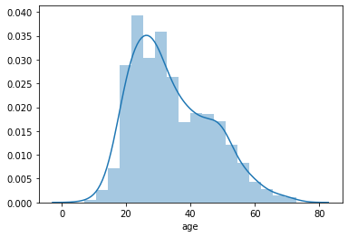

```python
sns.distplot(user['age']);
```

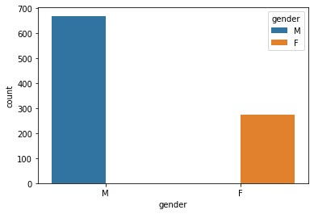

```python
sns.countplot(user['gender'], hue=user['gender']);
```

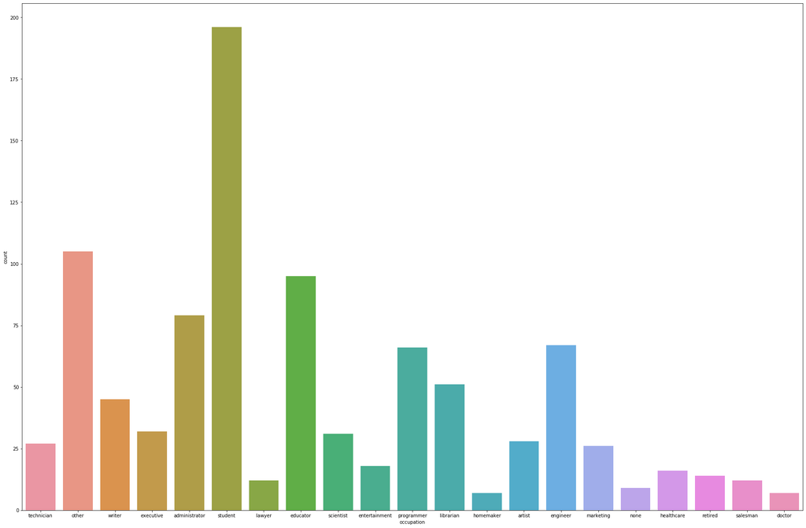

```python
plt.figure(figsize=(30,20))
sns.countplot(user['occupation']);
```

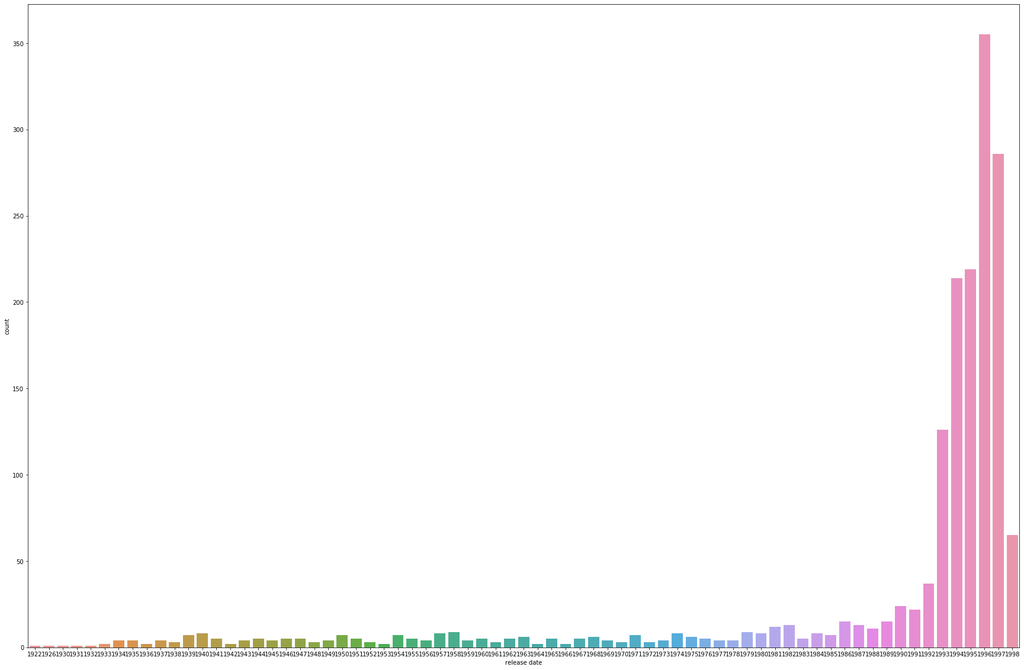

```python
item['release date'] = pd.DatetimeIndex(item['release date']).year
item.loc[(item['release date'] > 2021),'release date']=item['release date']-100
plt.figure(figsize=(30,20))
sns.countplot(item['release date']);
```

### 8. Visualize how popularity of genres has changed over the years - 10 marks

Note that you need to use the number of releases in a year as a parameter of popularity of a genre

Hint

1: you need to reach to a data frame where the release year is the index and the genre is the column names (one cell shows the number of release in a year in one genre) or vice versa. Once that is achieved, you can either use multiple bivariate plots or can use the heatmap to visualise all the changes over the years in one go.

Hint 2: Use groupby on the relevant column and use sum() on the same to find out the nuumber of releases in a year/genre.

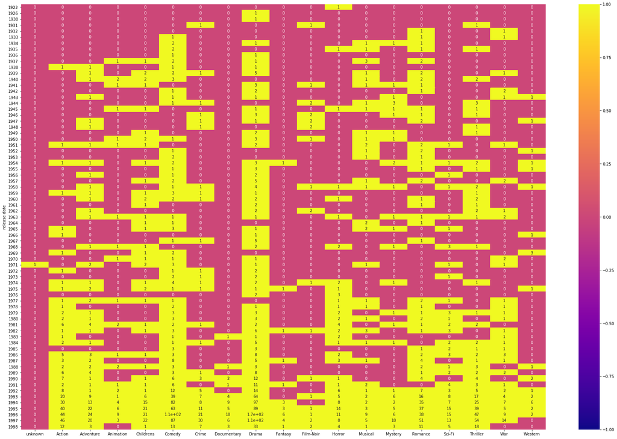

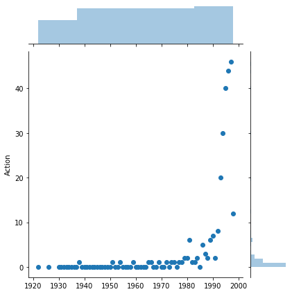

```python
item_temp = item.copy()
#item_temp['release date'] = item_temp['release date'].apply(lambda x: x.split('-')[2])
item_temp = item_temp.set_index('release date')
item_temp = item_temp.drop(['movie id'], axis=1)
item_new = item_temp.groupby('release date').sum()
item_new.head()
plt.figure(figsize=(30,20))
sns.heatmap(item_new, annot=True, cmap='plasma', vmin=-1, vmax=1)
plt.figure(figsize=(30,20))
sns.jointplot(data=item_new, x=item_new.index.values.tolist(), y='Action')
```

### 9. Find the top 25 movies according to average ratings such that each movie has number of ratings more than 100 - 10 marks

Hint :

1. First find the movies that have more than 100 ratings(use merge, groupby and count). Extract the movie id in a list.
2. Find the average rating of all the movies and sort them in the descending order. You will have to use the .merge() function to reach to a data set through which you can get the ids and the average rating.
3. Use isin(list obtained from 1) to filter out the movies which have more than 100 ratings.

Note: This question will need you to research about groupby and apply your findings. You can find more on groupby on https://realpython.com/pandas-groupby/.

```python
item_temp = item.copy()
item_new = item_temp.set_index('movie id')
data_item = pd.merge(data, item_new, how='right', on='movie id')
movie_review_data = pd.merge(data_item, user, how='right', on='user id')
movie_review_data_new = movie_review_data[movie_review_data.groupby('movie id')['movie id'].transform('count').ge(100)]
movie_review_data_new_mean = movie_review_data_new[['movie title', 'rating']].groupby('movie title').mean()
movie_review_data_new_mean_sorted = movie_review_data_new_mean.sort_values('rating', ascending=False)
print(movie_review_data_new_mean_sorted.head(25))
```

```
                                                      rating
movie title
Close Shave, A                                      4.491071
Schindler's List                                    4.466443
Wrong Trousers, The                                 4.466102
Casablanca                                          4.456790
Shawshank Redemption, The                           4.445230
Rear Window                                         4.387560
Usual Suspects, The                                 4.385768
Star Wars                                           4.358491
12 Angry Men                                        4.344000
Citizen Kane                                        4.292929
To Kill a Mockingbird                               4.292237
One Flew Over the Cuckoo's Nest                     4.291667
Silence of the Lambs, The                           4.289744
North by Northwest                                  4.284916
Godfather, The                                      4.283293
Secrets & Lies                                      4.265432
Good Will Hunting                                   4.262626
Manchurian Candidate, The                           4.259542
Dr. Strangelove or: How I Learned to Stop Worry...  4.252577
Raiders of the Lost Ark                             4.252381
Vertigo                                             4.251397
Titanic                                             4.245714
Lawrence of Arabia                                  4.231214
Maltese Falcon, The                                 4.210145
Empire Strikes Back, The                            4.204360
```

### 10. See gender distribution across different genres check for the validity of the below statements - 10 marks

- Men watch more drama than women
- Women watch more Sci-Fi than men
- Men watch more Romance than women
1. There is no need to conduct statistical tests around this. Just compare the percentages and comment on the validity of the above statements.
2. you might want ot use the .sum(), .div() function here.
3. Use number of ratings to validate the numbers. For example, if out of 4000 ratings received by women, 3000 are for drama, we will assume that 75% of the women watch drama.

#### Conclusion:

```python
# Verify Men watch more drama than women
total_men = movie_review_data[movie_review_data['gender'] == 'M'].shape[0]
total_women = movie_review_data[movie_review_data['gender'] == 'F'].shape[0]
no_of_men_watching_drama = \
movie_review_data[(movie_review_data['gender'] == 'M') & (movie_review_data['Drama'] == 1)].shape[0]
no_of_women_watching_drama = \
movie_review_data[(movie_review_data['gender'] == 'F') & (movie_review_data['Drama'] == 1)].shape[0]
percent_of_men_watching_drama = no_of_men_watching_drama * 100 / total_men
percent_of_women_watching_drama = no_of_women_watching_drama * 100 / total_women
print('Men watch more drama than women: {}'.format((percent_of_men_watching_drama > percent_of_women_watching_drama)))
print('Percent of Men watching Drame: {} \nPercent of Women watching Drame: {} '.format(percent_of_men_watching_drama,
                                                                                        percent_of_women_watching_drama))
```

```
Men watch more drama than women: False
Percent of Men watching Drame: 38.90347864732738
Percent of Women watching Drame: 42.76944595539669
```

```python
# Verify Women watch more Sci-Fi than men
no_of_men_watching_scifi = \
movie_review_data[(movie_review_data['gender'] == 'M') & (movie_review_data['Sci-Fi'] == 1)].shape[0]
no_of_women_watching_scifi = \
movie_review_data[(movie_review_data['gender'] == 'F') & (movie_review_data['Sci-Fi'] == 1)].shape[0]
percent_of_men_watching_scifi = no_of_men_watching_scifi * 100 / total_men
percent_of_women_watching_scifi = no_of_women_watching_scifi * 100 / total_women
print('Women watch more Sci-Fi than Men: {}'.format((percent_of_men_watching_scifi < percent_of_women_watching_scifi)))
print('Percent of Men watching Sci-Fi: {} \nPercent of Women watching Sci-Fi: {} '.format(percent_of_men_watching_scifi,
                                                                                          percent_of_women_watching_scifi))
```

```
Women watch more Sci-Fi than Men: False
Percent of Men watching Sci-Fi: 13.603490768049776
Percent of Women watching Sci-Fi: 10.214468878700753
```

```python
# Verify Men watch more Romance than women
no_of_men_watching_romance = \
movie_review_data[(movie_review_data['gender'] == 'M') & (movie_review_data['Romance'] == 1)].shape[0]
no_of_women_watching_romance = \
movie_review_data[(movie_review_data['gender'] == 'F') & (movie_review_data['Romance'] == 1)].shape[0]
percent_of_men_watching_romance = no_of_men_watching_romance * 100 / total_men
percent_of_women_watching_romance = no_of_women_watching_romance * 100 / total_women
print('Men watch more Roamnce than women: {}'.format(
    (percent_of_men_watching_romance > percent_of_women_watching_romance)))
print('Percent of Men watching Roamnce: {} \nPercent of Women watching Roamnce: {} '.format(
    percent_of_men_watching_romance, percent_of_women_watching_romance))
```

```
Men watch more Roamnce than women: False
Percent of Men watching Roamnce: 18.319798526658854
Percent of Women watching Roamnce: 22.760121221540135
```